# Representativeness in Music Corpus Studies

Music- and human-facing corpus building

Nicholas J. Shea

2024-11-08

## Part 1: Diversity versus representation

As part of a few of my recent projects, I introduced the *Popular Music Artist Demographic* database (*PMADD*) that catalogs various facets of popular-music artists’ identity along the lines of race, ethnicity, and gender (Nicholas J. Shea 2022). The current version of the database includes artist demographic information from the *Rolling Stone 200* (T. de Clercq and Temperley 2011a), *McGill Billboard Hot 100* (Burgoyne, Wild, and Fujinaga 2011), *Guitar Pro Tablature* (Nicholas Jordan Shea 2023), *Timbre in Popular Song* music-research databases, as well as those in the newly updated (2021) *Rolling Stone Magazine’s* “500 Greatest Hits of All Time” list (Nicholas J. Shea et al. 2024). We have since used this database to shape our artist populations (by genre) using a process called *stratified sampling* in the *Timbre in Popular Song* corpus.

One might understandably have some reservations about shaping corpora by demographics given the precedent in the field of music theory to prefer capturing repertoires by critical acclaim or commercial success. Trevor de Clercq recently offered a response to the data report that accompanied the *PMADD* (T. de Clercq 2023a). He raises the concern that dataset diversity is often in conflict with representation — in this case, that making sampling adjustments to promote a greater range of artist identities can undermine a corpus’s job of properly representing the population. In short, if we adjust for diversity, it may cause our corpus to skew too far from the broader population it is meant to capture. I’d like to thank Trevor for his response. He’s given me much to think about. I do agree with him, that it is important in corpus studies to maintain methodological rigor so we can assess trends objectively.

We can summarize differences along two lines — *music-facing* versus *human-facing* corpus development. de Clercq’s strictly *music-facing* stance emerges when he states “The population of glass vials […] has nothing to do with the population of people living in a country.” (p. 2) I read this statement as advocating that songs or the broader style to which these songs belong (e.g., “rock” music) should be methodologically separate from the people who contributed to the style. In short, *songs* are the population. In contrast, my colleagues and I have advocated for a more *human-facing* approach (Nicholas J. Shea et al. 2024).[^1] Our logic follows that genre is socially determined, and songs are written by artists who draw from said genres, so we can leverage the flexibility of genre to create more-inclusive corpora that perhaps better-reflect the broader *human population* of music-makers. Both approaches reflect a slightly different philosophy on corpus-building, but accomplish the same goal of generating collections that aim to capture the development of certain organizational trends over time.

## Part 2: What’s at stake statistically?

Today we’re going to explore what’s at stake when we build corpora around strictly *music-facing* versus more *human-facing* methods. To do so, we’ll focus on a somewhat trivial feature — introduction lengths — based on a hypothesis that introductions have become shorter over time (Léveillé Gauvin 2018). We’ll craft two 200-song corpora. The first will directly model de Clercq and Temperley’s (T. de Clercq and Temperley 2011b) methodology for generating the *Rolling Stone 200*, shaped by song rankings. Our second will emulate a new project conducted by a graduate student interested in how attention economy has changed over time, shaped by demographics.

By generating these two different samples, I hope to promote a productive discussion about where and where we do not permit methodological flexibility when we conduct corpus studies. Here are some questions I’d like you to consider as we move through the workshop:

- Is the new *Rolling Stone* list, focused on demographics, as “representative” as the older version, focused solely on rank?
- How do we tend to treat genre in music theory?
- Do artist identities correspond to, or perhaps influence, feature organization?

## Part 3: Generating the *Rolling Stone 200*

We’ll begin with the *RS5x20* corpus that samples the top-20 songs per decade (1950—1999). I have already compiled the two databases, so we’re just going to simulate how TdC and DT did so themselves. First, grab the top-20 songs per decade by rating

```r
RSall <- read.csv("RS2004-2021_intros.csv")
#make decade function by treating year as mod 10
floor_decade = function(value){ return(value - value %% 10) }
RSall$decade <- floor_decade(RSall$year)
#select 2004 version
RS2004 <- RSall %>%
  #select 2004 version
  filter(corpus == "2004")

#generate the RS5x20
RS5x20 <- RS2004 %>%
  #group by decade
  group_by(decade) %>%
  #grab top 20 ratings
  arrange(desc(rank)) %>%
  #remove anything pre-1950 and post-2000
  filter(year > "1949", year < "2000") %>%
  slice(1:20) #top 20 by ranking
```

Next, we’ll generate the remaining songs for the *RS200* by selecting the next 100 top-rated songs.

```r
#remove 5x20 from RS2004 so we don't sample it again
RS200 <- anti_join(RS2004,RS5x20) %>%
  #again remove decades out of scope
  filter(decade != "1940", decade != "2000") %>%
  #grab next 100 songs by rank
  arrange(desc(rank)) %>%
  slice(1:100)

#combine into one data set
RS200 <- rbind(RS200,RS5x20)
```

## Part 4: Attention economy study

Our graduate student music cognition researcher summarizes the following features of her study to her advisor.

- *hunch*: intro lengths decrease over time due to link between attention span and social media
- *question*: how does attention economy manifest in the general population?
- *prior knowledge*: listening habits are demographically coded (“How Black Audiences Are Engaging with Audio More Than Ever” 2022).
- *sample*: *Rolling Stone Magazine* 2021 list (hereby *RS2021*).
- *assumption*: artist compositional preferences in corpus reflect broader listening preferences
- *method*: align dataset diversity with population diversity per decade via Census data

To do so, she’ll necessarily need to generalize about listening habits between white and non-white listeners, so she chooses to rely on US Census data to shape her corpus sample accordingly.

**Disclaimer: census categories**

Now is a good time to acknowledge that US Census data is not perfect. The categories themselves are known to be inaccurate for some populations and, by extension, have harmed them (Nobles 2000). Ideally we’d have our popular-music artists self report their identities, like the Institute for Composer Diversity’s database, but instead we’ll have to rely on online sources as included in the *PMADD*. To draw our comparisons, Black, Indigenous, Hispanic, Asian, and Pacific Islander artists will be encompassed by the BIHAP demographic category in contrast to the White population.

## Part 5: Generating a 200-song sample from the *RS2021*

Our first step will be to determine the distribution of artists per decade.

```r
demo.table <- RSall %>%
  #filter to start at 1950
  filter(decade >= "1950") %>%
  #select 2021 version
  filter(corpus == "2021") %>%
  group_by(decade,BIHAP) %>%
  #count the number of artists per group, total number of artists
  dplyr::summarize(demo.count = n()) %>%
  dplyr::mutate(decade.count = sum(demo.count)) %>%
  #determine number of artists to sample per decade to maintain proportions
  dplyr::mutate(n.sample = round(decade.count*.4, digits = 0)) %>%
  mutate(RS2021 = round(demo.count/decade.count, digits = 3)) %>%
  filter(BIHAP == 1)
```

Let’s take a look at our table. `n.sample` indicates the number of songs we need to sample per decade to maintain the same proportions with the broader *RS2021* list.

```r
print(demo.table)
```

```
## # A tibble: 8 × 6
## # Groups:   decade [8]
##   decade BIHAP demo.count decade.count n.sample RS2021
##    <dbl> <int>      <int>        <int>    <dbl>  <dbl>
## 1   1950     1         14           24       10  0.583
## 2   1960     1         46          108       43  0.426
## 3   1970     1         43          144       58  0.299
## 4   1980     1         34           81       32  0.42
## 5   1990     1         30           70       28  0.429
## 6   2000     1         22           36       14  0.611
## 7   2010     1         19           32       13  0.594
## 8   2020     1          3            3        1  1
```

Now we need to compare our artist population distribution in the *RS2021* to the US Census’s.

```r
#read in Census data per decade
#read in Census data per decade
cen <- read.csv('US-Census-per-decade.csv')
cB <- cen$BIHAP
demo.table$census <- cB
n200<-demo.table$n.sample
#determine the number of artists needed to sample
#to maintain artist proportions/decade with Census
demo.table$n.BIHAP <- round(cB*n200, digits = 0)
demo.table$n.White <- round(n200-demo.table$n.BIHAP,digits = 0)
demo.table
```

```
## # A tibble: 8 × 9
## # Groups:   decade [8]
##   decade BIHAP demo.count decade.count n.sample RS2021 census n.BIHAP n.White
##    <dbl> <int>      <int>        <int>    <dbl>  <dbl>  <dbl>   <dbl>   <dbl>
## 1   1950     1         14           24       10  0.583  0.105       1       9
## 2   1960     1         46          108       43  0.426  0.114       5      38
## 3   1970     1         43          144       58  0.299  0.125       7      51
## 4   1980     1         34           81       32  0.42   0.169       5      27
## 5   1990     1         30           70       28  0.429  0.197       6      22
## 6   2000     1         22           36       14  0.611  0.249       3      11
## 7   2010     1         19           32       13  0.594  0.276       4       9
## 8   2020     1          3            3        1  1      0.384       0       1
```

### Sidebar: small sampling issue

- 2020 consists of all BIHAP artists
  - Megan Thee Stallion (Black, woman)
  - BTS (Korean, men)
  - Bad Bunny (Puerto Rican, man)

Because the original sample size is so small (*n* = 3), it is mathematically impossible to maintain the proportion between BIHAP and white artists (of which there are none).

To correct this, I’m going to modify `n.BIHAP` in the `demo.table` so that we can sample at least 2 artists.

```r
demo.table$n.BIHAP <- ifelse(demo.table$decade == "2020", 2, demo.table$n.BIHAP)
print(demo.table)
```

```
## # A tibble: 8 × 9
## # Groups:   decade [8]
##   decade BIHAP demo.count decade.count n.sample RS2021 census n.BIHAP n.White
##    <dbl> <int>      <int>        <int>    <dbl>  <dbl>  <dbl>   <dbl>   <dbl>
## 1   1950     1         14           24       10  0.583  0.105       1       9
## 2   1960     1         46          108       43  0.426  0.114       5      38
## 3   1970     1         43          144       58  0.299  0.125       7      51
## 4   1980     1         34           81       32  0.42   0.169       5      27
## 5   1990     1         30           70       28  0.429  0.197       6      22
## 6   2000     1         22           36       14  0.611  0.249       3      11
## 7   2010     1         19           32       13  0.594  0.276       4       9
## 8   2020     1          3            3        1  1      0.384       2       1
```

Let’s compare the proportion of BIHAP artists between the *RS2021* and Census data per decade.

```r
#shape the data so we can easily compare prop between categories
#RS2021 versus Census proportion of BIHAP folks
prop.plot<-gather(data = demo.table, key = collection, value = prop, RS2021, census)
#generate the plot
prop.plot<-ggplot(prop.plot, aes(decade, prop, fill = collection)) +
  geom_col(position= "dodge")
```

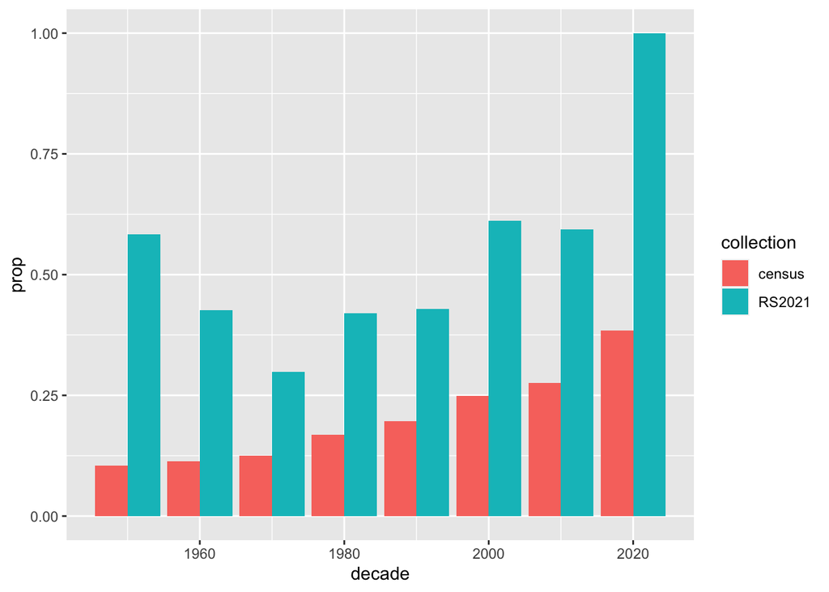

```r
print(prop.plot)
```

As we can see, the *RS2021* over represents songs by BIHAP artists in each decade. However, note this is by *song* as associated with the artist’s identity. We would have different data if we controlled for artist identity per decade, e.g., setting a sampling limit (artist cannot appear more that *x* times per decade).

## Part 6: Stratified sampling in the literature

*Stratified sampling* is legitimate technique to address inherited biases in preexisting sources by aligning dataset diversity with real-world diversity. Data from an assumedly non-representative population is compiled then processed to become more representative “by adjusting the sample to have the same distribution of these variables as the population” (Alsalti et al. 2023) (p. 4)

#### Examples

- (Wang et al. 2015) predicted the results of the 2012 US presidential election from a demographically skewed sample of Xbox gamers.
  - disproportionately male
  - performed better than true probability or “raw” sampling
- (Fareed et al. 2022) compile, sort, and synthesize a variety of public databases to connect outreach organizations with Black mothers whose infants are at a nearly three times greater risk of premature death than white infants.
- Iterations of the Goldsmiths *Music Sophistication Index* have used post-hoc stratified sampling to adapt the index for various cultures (e.g., (Lin et al. 2021); (Degrave and Dedonder 2019); (Fiedler and Müllensiefen 2015)).

## Part 7: Stratified sampling in the *RS2021*

Based on our data from `demo.table` we now have the ability to sample artists by race/ethnicity (BIHAP) per decade in proportion with the original population distribution in the broader *Rolling Stone 2021* list.

First, let’s select the 2021 version of the corpus

```r
#select the RS2021
RS2021 <- RSall %>%
  #select 2021 version
  filter(corpus == "2021")
```

Then we’ll create a blank data frame that we can add our samples onto.

```r
#create an empty dataframe first
r2021_200 <- data.frame(matrix(ncol = 10, nrow = 0))
#set column names
x <- c("artist", "title", "primary.status", "BIHAP", "gender", "year", "corpus", "total", "rank", "decade")
colnames(r2021_200) <- x
```

Last, we’ll use a *for loop* to cycle over the *RS2021* by `decade` and sample the total number of artists according to the `n.BIHAP` and `n.White` columns of our `demo.table` data.

```r
#begin for loop
for (i in 1:8)
{
d <- demo.table$decade[[i]]
no.b <- demo.table$n.BIHAP[[i]]
no.w <- demo.table$n.White[[i]]
rdec <- RS2021 %>% filter(decade == d)
s.b <- stratified(rdec, c("BIHAP"), size = no.b, select = list(BIHAP = 1), replace = FALSE)
s.w <- stratified(rdec, c("BIHAP"), size = no.w, select = list(BIHAP = 0), replace = FALSE)
sample<-rbind(s.b,s.w)
r2021_200<-rbind(r2021_200,sample)
}
```

We’re then left with a 200-song sample from the *RS2021* that maintains the distribution of BIHAP and white artists per decade.

```r
print(r2021_200)
```

```
##                                 artist                   title primary.status
##   1:                       Fats Domino          Blueberry Hill              1
##   2:                       Buddy Holly               Peggy Sue              0
##   3:                     Hank Williams     Your Cheatin' Heart              0
##   4:                     Eddie Cochran        Summertime Blues              0
##   5:                       Johnny Cash         I Walk the Line              0
##  ---
## 196:                      Harry Styles       Sign of the Times              0
## 197:                   Miranda Lambert The House That Built Me              1
## 198:                       Eric Church             Springsteen              0
## 199:                               BTS                Dynamite              1
## 200: Megan Thee Stallion feat. Beyonce          Savage (Remix)              1
##      BIHAP gender year corpus total rank decade
##   1:     1      0 1956   2021    10  147   1950
##   2:     0      0 1958   2021     8  370   1950
##   3:     0      0 1953   2021     6  237   1950
##   4:     0      0 1958   2021    10  432   1950
##   5:     0      0 1956   2021    29   76   1950
##  ---
## 196:     0      0 2017   2021    16  428   2010
## 197:     0      1 2010   2021    20  441   2010
## 198:     0      0 2011   2021     9  391   2010
## 199:     1      0 2020   2021     9  346   2020
## 200:     1      1 2020   2021     2  438   2020
```

## Part 8: Analysis

In this section, we aim to model changes in introduction length (`total`) over time (`year`). Because we have data from each 200-song sample (*RS200* and *RS2021*), we can compare the intercepts of each collection to assess differences by eye (at first).

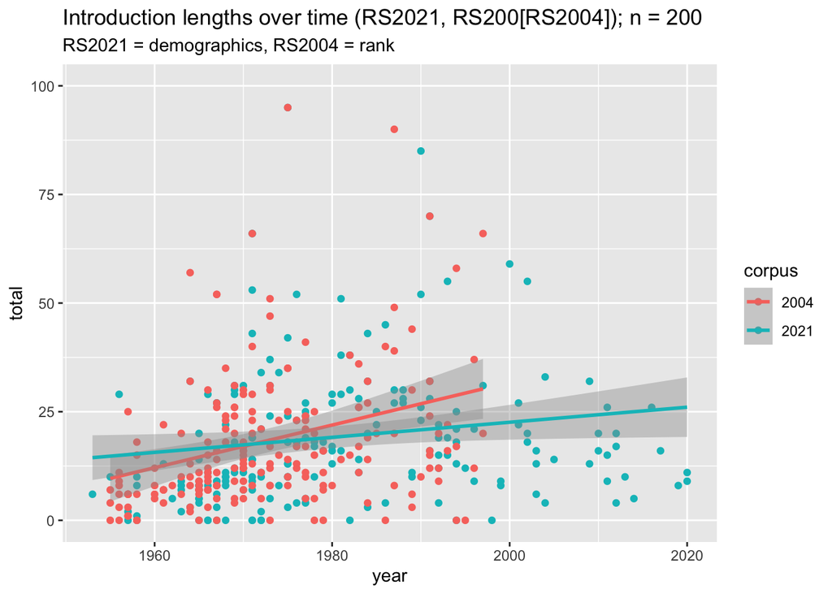

```r
#combine 200-song samples
RS <- rbind(r2021_200,RS200)
#make sure corpus is treated as a factor
RS$corpus <- as.factor(RS$corpus)
#plot differences based on linear model
lm.plot <- RS |>
  ggplot(aes(x = year, y = total, color = corpus )) +
  geom_point() +
  geom_smooth(method = "lm") +
  labs(title="Introduction lengths over time (RS2021, RS200[RS2004]); n = 200",subtitle="RS2021 = demographics, RS2004 = rank") +
  #"Cortez the Killer" by Neil Young has a 203-sec intro, let's limit y axis
  coord_cartesian(ylim = c(0,100), default = FALSE)
print(lm.plot)
```

Then we can compile this data into a linear model to see if there are any significant interactions between introduction lengths (`total`), time (`year`), and a given corpus (`corpus`).

```r
#create model
model <- lm(total ~ year*corpus, data = RS)
#test model
summary(model)
```

```
##
## Call:
## lm(formula = total ~ year * corpus, data = RS)
##
## Residuals:
##     Min      1Q  Median      3Q     Max
## -29.276 -10.031  -5.322   4.160 183.533
##
## Coefficients:
##                  Estimate Std. Error t value Pr(>|t|)
## (Intercept)     -949.1553   259.3885  -3.659 0.000287 ***
## year               0.4904     0.1315   3.730 0.000220 ***
## corpus2021       715.0314   314.8436   2.271 0.023679 *
## year:corpus2021   -0.3624     0.1594  -2.274 0.023515 *
## ---
## Signif. codes:  0 '***' 0.001 '**' 0.01 '*' 0.05 '.' 0.1 ' ' 1
##
## Residual standard error: 19.66 on 396 degrees of freedom
## Multiple R-squared:  0.03947,    Adjusted R-squared:  0.03219
## F-statistic: 5.423 on 3 and 396 DF,  p-value: 0.001153
```

## Part 9: Interpreting results

So how can we interpret these results?

- By eye, we can see that the *corpora have different intercepts*, suggesting that introduction lengths are not treated the same over time between the two collections.
- Indeed, we have a main effect of corpus *`corpus2021`* and a significant interaction between year and corpus `year:corpus2021` such that there is a statistical difference between the two.
- Our summary model also suggests a *main effect of year* (song intros appear to increase as time goes on within bounds of sample)

## Part 9: Caveats

Some caveats:

- Our chronological spans are not the same. *RS200* is 1955-1999. *RS2021* is 1950-2020.
- Differences may just be a matter of an increased scope.
- Because our sample size is so small (*n* = 200) we have the option of removing outliers.

## Part 10: Entire-corpora analysis

- Newest *Rolling Stone* list (2021) expands:
  - artists represented
  - chronological scope
  - BIHAP artists are “tacked on” pre-1950 and post-1999 (Shea et al 2024)

What’s the difference between the two (complete) lists?

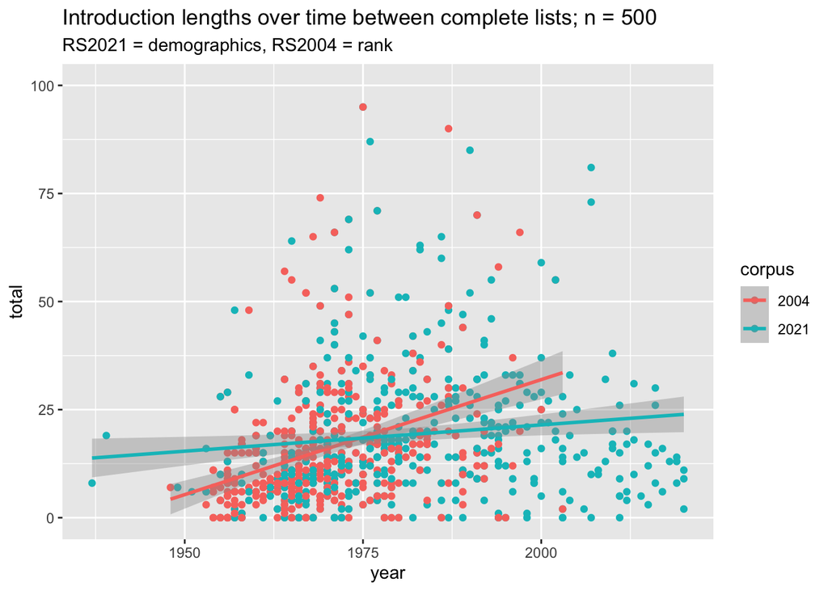

```r
RSall$corpus <- as.factor(RSall$corpus)
lm.plot <- RSall |>
  ggplot(aes(x = year, y = total, color = corpus)) +
  geom_point() +
  geom_smooth(method = "lm") +
  labs(title="Introduction lengths over time between complete lists; n = 500",
       subtitle="RS2021 = demographics, RS2004 = rank") +
  #"Cortez the Killer" by Neil Young has a 203-sec intro, let's limit y axis
  coord_cartesian(ylim = c(0,100), default = FALSE)
print(lm.plot)
```

## Part 11: Post-hoc analysis [1/8]

In some ways we are comparing apples to oranges.

- The *RS200* prioritizes song rank. The *RS2021* is shaped around demographics.
- It would be productive to see if…
  - The complete *RS2004* reflects intro lengths by year if we shape the corpus by *demographics*.
  - The complete *RS2021* reflects intro lengths by year if we shape the corpus by *rank*.

### Reshape the *n* = 200 sample for RS2021 by rank

```r
#read in database
RSall <- read.csv("RS2004-2021_intros.csv")
#make decade function by treating year as mod 10
floor_decade = function(value){ return(value - value %% 10) }
RSall$decade <- floor_decade(RSall$year)
#select 2004 version
RS2021d <- RSall %>%
  #select 2004 version
  filter(corpus == "2021")
```

## Part 11: Post-hoc analysis [2/8]

### Reshape the *n* = 200 sample for RS2021 by rank

```r
#generate the RS5x20
RS5x20_21 <- RS2021d %>%
  #group by decade
  group_by(decade) %>%
  #grab top 20 ratings
  arrange(desc(rank)) %>%
  #remove anything pre-1950 and post-2000
  filter(year > "1949", year < "2000") %>%
  slice(1:20)
```

## Part 11: Post-hoc analysis [3/8]

### Reshape the *n* = 200 sample for RS2021 by rank

```r
#remove 5x20 from RS2004 so we don't sample it again
RS2021_100 <- anti_join(RS2021d,RS5x20_21) %>%
  #again remove decades out of scope
  filter(decade != "1940", decade != "2000") %>%
  #grab next 100 songs by rank
  arrange(desc(rank)) %>%
  slice(1:100)

#combine into one data set
RS2021_200 <- rbind(RS2021_100,RS5x20_21)
rm(RS2021d,RS5x20_21)
```

## Part 11: Post-hoc analysis [4/8]

### Reshape the *n* = 200 sample for RS2004 by *demographics*

```r
#determine proportion for RS2021
demo.table <- RSall %>%
  #filter to start at 1950
  filter(decade >= "1950", year <= "2004") %>%
  #select 2021 version
  filter(corpus == "2004") %>%
  group_by(decade,BIHAP) %>%
  #count the number of artists per group, total number of artists
  dplyr::summarize(demo.count = n()) %>%
  dplyr::mutate(decade.count = sum(demo.count)) %>%
  #determine number of artists to sample per decade to maintain proportions
  dplyr::mutate(n.sample = round(decade.count*.4, digits = 0)) %>%
  mutate(RS2021 = round(demo.count/decade.count, digits = 3)) %>%
  filter(BIHAP == 1)
```

## Part 11: Post-hoc analysis [5/8]

### Reshape the *n* = 200 sample for RS2004 by *demographics*

```r
#select the RS2021
RS2004 <- RSall %>%
  #select 2021 version
  filter(corpus == "2004")

#create an empty dataframe first
r2004_200 <- data.frame(matrix(ncol = 10, nrow = 0))
#set column names
x <- c("artist", "title", "primary.status", "BIHAP",
       "gender", "year", "corpus", "total", "rank", "decade")
colnames(r2004_200) <- x
```

## Part 11: Post-hoc analysis [6/8]

### Reshape the *n* = 200 sample for RS2004 by *demographics*

```r
#read in Census data per decade
cen <- read.csv("US-Census-per-decade.csv")
cen <- cen %>% filter(Decade != "2010", Decade != "2020")
cB <- cen$BIHAP
demo.table$census <- cB
n200<-demo.table$n.sample
#determine the number of artists needed to sample
#to maintain artist proportions/decade with Census
demo.table$n.BIHAP <- round(cB*n200, digits = 0)
demo.table$n.White <- round(n200-demo.table$n.BIHAP,digits = 0)
```

## Part 11: Post-hoc analysis [7/8]

### Reshape the *n* = 200 sample for RS2004 by *demographics*

```r
#begin for loop
for (i in 1:6)
{
#set decade for this iteration
d <- demo.table$decade[[i]]
#grab n artists per demographic group
no.b <- demo.table$n.BIHAP[[i]]
no.w <- demo.table$n.White[[i]]
#select the correct decade from the RS2021
rdec <- RS2004 %>% filter(decade == d)
#sample according to race/ethnicity distribution from demo.table
s.b <- stratified(rdec, c("BIHAP"), size = no.b, select = list(BIHAP = 1), replace = FALSE)
s.w <- stratified(rdec, c("BIHAP"), size = no.w, select = list(BIHAP = 0), replace = FALSE)
#join sample groups together
sample<-rbind(s.b,s.w)
#add to existing data frame
r2004_200<-rbind(r2004_200,sample)
}
```

## Part 11: Post-hoc analysis [8/8]

```r
#combine 200-song samples
RS <- rbind(r2021_200,r2004_200)
#make sure corpus is treated as a factor
RS$corpus <- as.factor(RS$corpus)
#plot differences based on linear model
lm.plot <- RS |>
  ggplot(aes(x = year, y = total, color = corpus )) +
  geom_point() +
  geom_smooth(method = "lm") +
  labs(title="Introduction lengths over time (RS2021, RS200); n = 200", subtitle="RS2021 = rank, RS2004 = demographics") +
  #"Cortez the Killer" by Neil Young has a 203-sec intro, let's limit y axis
  coord_cartesian(ylim = c(0,100), default = FALSE)
RS$corpus <- as.factor(RS$corpus)
RS$total <- as.numeric(RS$total)
RS$year <- as.numeric(RS$year)
model <- lm(total ~ year*corpus, data = RS)
```

## Part 11: Post-hoc analysis [8/8]

```
##
## Call:
## lm(formula = total ~ year * corpus, data = RS)
##
## Residuals:
##     Min      1Q  Median      3Q     Max
## -27.995  -9.021  -3.831   4.993 100.418
##
## Coefficients:
##                  Estimate Std. Error t value Pr(>|t|)
## (Intercept)     -942.6536   234.8684  -4.014 7.16e-05 ***
## year               0.4865     0.1192   4.081 5.42e-05 ***
## corpus2021       618.5592   279.0009   2.217   0.0272 *
## year:corpus2021   -0.3132     0.1414  -2.215   0.0273 *
## ---
## Signif. codes:  0 '***' 0.001 '**' 0.01 '*' 0.05 '.' 0.1 ' ' 1
##
## Residual standard error: 16.59 on 395 degrees of freedom
## Multiple R-squared:  0.0614, Adjusted R-squared:  0.05427
## F-statistic: 8.614 on 3 and 395 DF,  p-value: 1.498e-05
```

[figure not shown]

```r
lm.plot
```

## Part 12: Discussion

### **Discussion questions**

Is the new *RS* list as “representative” as the older version? Why or why not?

- How do we tend to treat genre in music theory?
- Do artist identities correspond to, or perhaps influence, feature organization?
- What else may be at play to cause differences between the two lists?

## Part 11: Discussion

#### Questions to consider

- Is the new *Rolling Stone* list as “representative” as the older version? Why or why not?
- How do we tend to treat genre in music theory?
- Do artist identities correspond to, or perhaps influence, feature organization?

#### Wrap-up: why sample?

- sampling is used when we can’t capture an entire population
- testing is used to assess if norms meet predetermined expectations
- Example: Bach chorales
  - We have the ability to test trends in all Bach chorales
  - Therefore we don’t need tests, just to infer
  - Yet, skeptical when we say Bach reflects all classical music
  - Bach is not necessarily *representative* of all voice leading

#### It is impossible to capture the totality of popular music

- …so we use corpora instead
- every time we do this we introduce bias
- we can take certain steps to reduce biases
  - RS5x20: sample equally from each decade
  - Here: align dataset population with US Census data

#### *Rolling Stone*: representative of what?

- Listening habits of “industry professionals” who prefer songs…
  - in the “classic rock” canon
  - premiered ca. 1965—1985
  - written/performed by men
  - of critical acclaim and/or commercial success
- *RS200*: representative of what?
  - expert perspective on harmony, melody, form
  - “rock” music that includes a variety of subgenres

#### Where do we permit flexibility?

- *RS200* represents “rock” music
- “Rock” genre label is treated as catch-all for various sub-genres
- rap and hip hop are underrepresented in the *RS200* due to
  - limited chronological span (1949—1999)
  - lopsided chronological distribution (rap is newer)
  - all corpora become outdated as time passes, not an intentional fault
- RS2024 list
  - expands chronological span (1935-2021)
  - more songs by artists of color, esp. post 1999

#### So, is the *RS200* more/less representative than our *RS2021* sample?

- We already have a flexible framework for “rock” music
  - does more hip hop and rap mean less “rock”-like?
  - if so, maybe we start using “hip hop” or “rap” as our catch-all label given the modern influence of hip hop on musical organization (Fornas 1995)
- Ultimately depends on your **research question**, which informs your *population* selection
  - TdC (2023), “The statistical population for a corpus study is a set of songs, typically the set of songs belonging to some particular musical style or era.” (T. de Clercq 2023b)
  - *RS2021* expands the population of songs in consideration of the *human-facing* elements of style development.
  - May not be a perfect approach, more-diverse folks are tacked on before 1950 and after 1999.
  - Captures modern popular music nevertheless, even while prioritizing diversity.

## Works Cited

Alsalti, Taym, Ian Hussey, Malte Elson, and Ruben C. Arslan. 2023. “Using Multilevel Regression and Poststratification to Efficiently Derive Accurate Norms,” October. https://doi.org/10.31234/osf.io/fcm3n.

Burgoyne, John Ashley, Jonathan Wild, and Ichiro Fujinaga. 2011. “An Expert Ground-Truth Set for Audio Chord Recognition and Music Analaysis.” *12th International Society for Music Information Retrieval Conference*, s, 6. https://doi.org/https://ismir2011.ismir.net/papers/OS8-1.pdf.

Clercq, Trevor de. 2023a. “Representation in Corpus Studies of Music: Commentary on Shea’s (2022) "A Demographic Sampling Model and Database for Addressing Racial, Ethnic, and Gender Bias in Popular-Music Empirical Research".” *Empirical Musicology Review* 18 (2): 175–80. https://doi.org/10.18061/emr.v18i2.9726.

———. 2023b. “Representation in Corpus Studies of Music: Commentary on Shea’s (2022) "A Demographic Sampling Model and Database for Addressing Racial, Ethnic, and Gender Bias in Popular-Music Empirical Research".” *Empirical Musicology Review* 18 (2): 175–80. https://doi.org/10.18061/emr.v18i2.9726.

Clercq, Trevor de, and David Temperley. 2011a. “A Corpus Analysis of Rock Harmony.” *Popular Music* 30 (1): 47–70. https://doi.org/10.1017/S026114301000067X.

———. 2011b. “A Corpus Analysis of Rock Harmony.” *Popular Music* 30 (1): 47–70. https://doi.org/10.1017/S026114301000067X.

Degrave, Pauline, and Jonathan Dedonder. 2019. “A French Translation of the Goldsmiths Musical Sophistication Index, an Instrument to Assess Self-Reported Musical Skills, Abilities and Behaviours.” *Journal of New Music Research* 48 (2): 138–44. https://doi.org/10.1080/09298215.2018.1499779.

Fareed, Naleef, Christine M. Swoboda, John Lawrence, Tyler Griesenbrock, and Timothy Huerta. 2022. “Co-Establishing an Infrastructure for Routine Data Collection to Address Disparities in Infant Mortality: Planning and Implementation.” *BMC Health Services Research* 22 (1): 4. https://doi.org/10.1186/s12913-021-07393-1.

Fiedler, Daniel, and Daniel Müllensiefen. 2015. “Validierung des Gold-MSI-Fragebogens zur Messung Musikalischer Erfahrenheit von Schülerinnen und Schülern der Sekundarstufen an allgemeinbildenden Schulen.”

Fornas, Johan. 1995. “The future of rock: discourses that struggle to define a genre.” *Popular music* 14 (1): 111125. https://doi.org/10.1017/S0261143000007650.

“How Black Audiences Are Engaging with Audio More Than Ever.” 2022. https://www.nielsen.com/insights/2022/how-black-audiences-are-engaging-with-audio-more-than-ever/.

Léveillé Gauvin, Hubert. 2018. “On Popular Music and Media: Analyzing Changes in Compositional Practices and Music Listening Choice Behavior Using Attention Economy Principles.” PhD thesis. https://etd.ohiolink.edu/acprod/odb_etd/etd/r/1501/10?clear=10&p10_accession_num=osu1523284232353463.

Lin, Hsin-Rui, Reinhard Kopiez, Daniel Müllensiefen, and Anna Wolf. 2021. “The Chinese Version of the Gold-MSI: Adaptation and Validation of an Inventory for the Measurement of Musical Sophistication in a Taiwanese Sample.” *Musicae Scientiae* 25 (2): 226–51. https://doi.org/10.1177/1029864919871987.

Nobles, Melissa. 2000. *Shades of Citizenship: Race and the Census in Modern Politics*. Stanford University Press.

Shea, Nicholas J. 2022. “A Demographic Sampling Model and Database for Addressing Racial, Ethnic, and Gender Bias in Popular-Music Empirical Research.” *Empirical Musicology Review* 17 (1): 49–58. https://doi.org/10.18061/emr.v17i1.8531.

Shea, Nicholas Jordan. 2023. “"Guitar Thinking" and "Genre Thinking" Among an Online Community of Guitarists.” *IASPM Journal* 13 (1): 45–76. https://doi.org/10.5429/2079-3871(2023)v13i1.4en.

Shea, Nicholas J., Lindsey Reymore, Christopher WM White, Benjamin Duinker, Leigh Van Handel, Matthew Zeller, and Nicole Biamonte. 2024. “Diversity in Musical Corpus Studies.” *Music Theory Online* 30 (1). https://mtosmt.org/issues/mto.24.30.1/mto.24.30.1.shea_et_al.html.

Wang, Wei, David Rothschild, Sharad Goel, and Andrew Gelman. 2015. “Forecasting Elections with Non-Representative Polls.” *International Journal of Forecasting* 31 (3): 980–91. https://doi.org/10.1016/j.ijforecast.2014.06.001.

[^1]: *(As we underscore throughout the article, our approach is **non-prescriptive** and is **germane to our research question**. We explicitly acknowledge it is not appropriate for all circumstances.)